# 3a_SI_und_SIR

## SI-Modell und SIR-Modell

Im Folgenden soll die Verbreitung von COVID-19 anhand von Kompartimentmodellen dargestellt werden.

## Logistisches Wachstumsmodell - SI-Modell

Das Modell teilt die Gesamtbevölkerung in zwei Gruppen:  
S: susceptibles (Gefährdeten)  
I: infected (Infizierten).  
Dabei berechnet sich S wie folgt:  
\begin{eqnarray} S(t) = (B-I(t)) \end{eqnarray}

In diesem Modell kann die Anzahl der Infizierten nicht die Anzahl der Bevölkerung übersteigen. Der Anstieg der Infizierten ist beendet, wenn die Population der Infizierten die Gesamtpopulation erreicht (Infiziertenpopulation ist gesättigt).

Es gelten folgende Gleichungen: \begin{eqnarray} S'(t)=-k*S(t)*I(t)\\ I'(t)=k*S(t)*I(t) \\ S(t_0)=B-I_0\\ I(t_0)=I_0\\ \end{eqnarray} wobei \begin{eqnarray} k=\frac{c}{B} \end{eqnarray} der Infektionsrate entspricht. Diese beschreibt die Wahrscheinlichkeit mit der sich die Infektion von einem aktuell Infizierten auf neue Infizierte in einer Zeiteinheit überträgt (Rate der Infektionsverbreitung bei einer Kontaktrate: Wahrscheinlichkeit des Kontakts eines Infizierten mit einem Anfaelligen.).  
B entspricht der Gesamtbevölkerung

Das Erhaltungsgesetz \begin{eqnarray} S'(t)+I'(t)=0 \end{eqnarray} beschreibt, dass die Gesamtpopulation \begin{eqnarray} S(t)+I(t)=B \end{eqnarray} konstant erhalten bleibt.

### 0. Corona Daten vom RKI

```matlab
% Last Date: 12.4.2020
function y= coronaData ()
	infects = [    16.0     18.0     21.0     26.0     53.0     66.0    117.0    150.0    188.0    240.0    400.0    639.0    795.0    902.0   1139.0   1296.0   1567.0   2369.0   3062.0   3795.0   4838.0   6012.0   7156.0   8198.0  10999.0  13957.0  16662.0  18610.0  22672.0  27436.0  31554.0  36508.0  42288.0  48582.0  52547.0  57298.0  61913.0  67366.0  73522.0  79696.0  85778.0  91714.0  95391.0  99225.0 103228.0 108202.0 113525.0 117658.0 120479.0 123016.0 125098.0 127584.0 130450.0 133830.0 137439.0 139897.0 141672.0 143457.0 145694.0 148046.0 150383.0 152438.0 154175.0 155193.0 156337.0 157641.0 159119.0 160758.0 161703.0 162496.0 163175.0 163860.0 164807.0 166091.0 167300.0 168531.0 169218.0];
	deads = [   0.0    0.0    0.0    0.0    0.0    0.0    0.0    0.0    0.0    0.0    0.0    0.0    0.0    0.0    0.0    0.0    0.0    0.0    0.0    0.0    0.0    0.0    0.0   12.0   20.0   31.0   46.0   55.0   86.0  114.0  149.0  198.0  253.0  325.0  389.0  455.0  583.0  732.0  872.0 1017.0 1158.0 1342.0 1434.0 1607.0 1861.0 2107.0 2373.0 2544.0 2673.0 2799.0 2969.0 3254.0 3569.0 3868.0 4110.0 4294.0 4404.0 4598.0 4879.0 5094.0 5321.0 5500.0 5640.0 5750.0 5913.0 6115.0 6288.0 6481.0 6575.0 6649.0 6692.0 6831.0 6996.0 7119.0 7266.0 7369.0 7395.0];
    recovered = [0.0, 0.0, 0.0, 0.0, 0.0, 0.0, 0.0, 0.0, 0.0, 0.0, 0.0, 0.0, 0.0, 0.0, 0.0, 0.0, 0.0, 0.0, 0.0, 0.0, 0.0, 0.0, 0.0, 0.0, 0.0, 0.0, 0.0, 0.0, 0.0, 0.0, 0.0, 0.0, 0.0, 0.0, 0.0, 13500.0, 16100.0, 18700.0, 21400.0, 23800.0, 26400.0, 28700.0, 30600.0, 33000.0, 46300.0, 49000.0, 53913.0 57400.0 60200.0 64300.0 68200.0 72600.0 77000.0 81800.0 85400.0 88000.0 91500.0 95200.0 99400.0 103300.0 106800.0 109800.0 112000 114500 117400.0 120400.0 123500.0 126900.0 129000.0 130600.0 132700.0 135100.0 137400.0 139900.0 141700.0 143300.0 144400.0];
	y=[infects;deads;recovered];
endfunction
```

### 1. Schritt: Parameter implementieren

Wir betrachten 2/3 der Gesamtbevölkerung Deutschlands (83 Mio), die sich infizieren können, also 55 Mio.

```matlab
% Erkrankungsrate: Rate der Infektionsverbreitung
c = 0.3238;
c_vector = [0.3238];

% Wechselrate von Infizierten zu Genesenen
w = 1/14;

% Zahl der Bevoelkerung, die potenziell infiziert werden kann (=2/3 der Gesamtbevoelkerung) in Deutschland
B = 55000;    %in Tausend

%Prozentualanteil der erfassten Infizierten
r=1;

% Todesrate
d=0;

% Zeitschritte
times = (0:0.1:180); %betrachtet 180 Tage in 0.1 Schritten

%Startwert Infizierte
I_0= 16/1000; % 16 Infizierte
```

#### 2. Schritt: Implementation der numerischen Lösung der Differentialgleichungen des SI-Modells

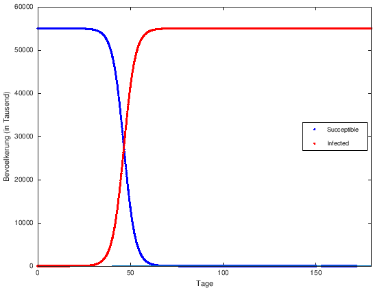

```matlab
% Anfangswerte als Spaltenvektor für S und I erstellen
z0=[B-I_0; I_0];

% Funktion g der rechten Seite des DGL-Systems y'=g(y,t)
g=@(z,t)[-c*z(1)*z(2)/B; c*z(1)*z(2)/B];

%Löst das DGL-System
z = lsode (g, z0, times); %lsode (linear solve ordinary differential equations) löst ein System gewöhnlicher Differentialgleichungen mit adequaten numerischen Methoden.

plot (times, z (:,1),'b.',times, z (:,2), 'r.', times) % : alle Einträge der Zeilen (wenn : an erster Stelle steht)
 legend ("Succeptible","Infected", "location", "east")
 xlabel ('Tage')
 ylabel ('Bevoelkerung (in Tausend)')
 axis([0,180, 0 ,60000])
```

##### Betrachtung unterschiedlicher Erkrankungsraten

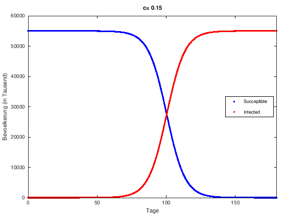

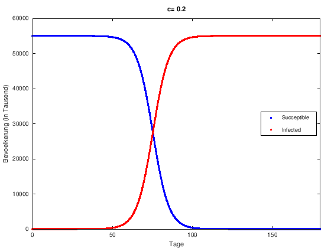

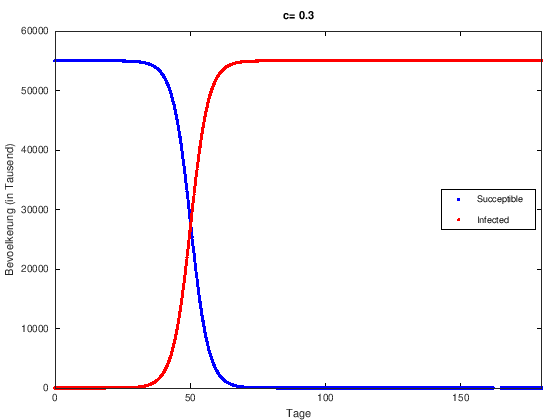

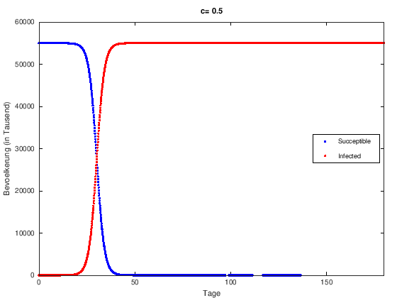

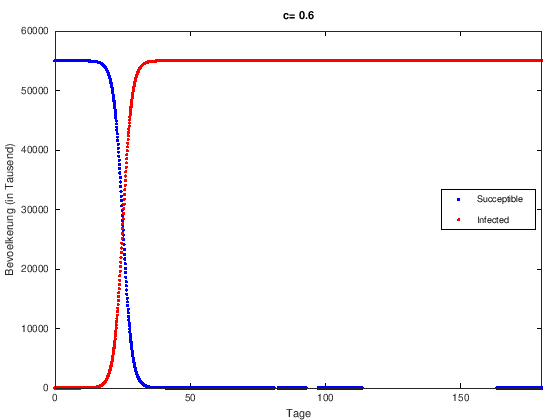

```matlab
% Anfangswerte als Spaltenvektor für S und I erstellen
z0=[B-I_0; I_0];

c_v=[0.6,0.5, 0.3, 0.2, 0.15];
for i=1:length(c_v)
    c=c_v(i);

    % Funktion g der rechten Seite des DGL-Systems y'=g(y,t)
    g=@(z,t)[-c*z(1)*z(2)/B; c*z(1)*z(2)/B];

    %Löst das DGL-System
    z = lsode (g, z0, times);

    %Plotten der Funktionen
    figure(i) %ordnet dem Bild eine Nummer zu, dass mehrere Bilder bekommt
    plot (times, z (:,1),'b.',times, z (:,2), 'r.')% : alle Einträge der Zeilen (wenn : an erster Stelle steht)
    title (["c= " num2str(c)])
     legend ("Succeptible","Infected", "location", "east")
     xlabel ('Tage')
     ylabel ('Bevoelkerung (in Tausend)')
     axis([0,180, 0 ,60000])
endfor
```

#### Ergebnis

Die verschiedenen Erkrankungsrate zeigen große Unterschiede hinsichtlich der Infektionsverbreitung. Je kleiner die Erkrankungsrate ist, desto langsamer verläuft die Infektionsverbreitung. Dementsprechend folgt, dass je größer die Erkrankungsrate ist, desto schneller verläuft die Infektionverbreitung.

#### Kritik

- Modell betrachtet nur 2 Gruppen (kumulierte Infizierte, Gefährdete)
- Zahl der aktuell Infizierten ist nicht darstellbar -> wichtige Zahl für Gesundheitssystem -> Überlastung
- konstantes c bildet Realität nicht ab (Kontaktverbot, Auswirkungen der Maßnahmen)

## SIR - Modell

S: susceptibles (Gefährdete)  
I: infected (Infizierte)  
R: recovered (Genesene)

Diese Modell betrachtet eine weitere Gruppe der recovered (Genesenen), die nach der Genesung von der Gruppe der Infizierten in die Gruppe der Genesenen mit einer bestimmten Rate w wechseln.

Es gelten die folgenden Gleichungen: \begin{eqnarray} S'(t)=-k*S(t)*I(t)\\ I'(t)=k*S(t)*I(t)-w*I(t) \\ R'(t)=w*I(t)\\ \end{eqnarray} Dabei ist \begin{eqnarray} w=\frac{1}{T} \end{eqnarray} der Umkehrwert der Genesungszeit T. Diese wird hier als 14 angenommen, da laut Studien ein Infizierter 14 Tage ansteckbar ist.

Das Erhaltungsgesetz \begin{eqnarray} S'(t)+I'(t)+R'(t)=0 \end{eqnarray} beschreibt, dass die Gesamtpopulation \begin{eqnarray} S(t)+I(t)+R(t)=B \end{eqnarray} konstant erhalten bleibt.

#### Implementation der numerischen Lösung der Differentialgleichungen des SIR- Modells

##### bei Betrachtung unterschiedlicher Erkrankungsraten

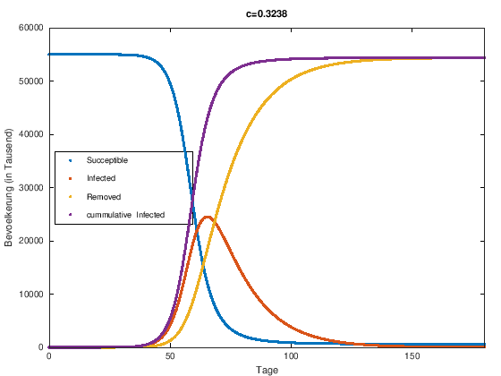

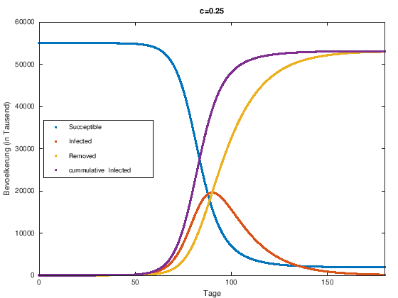

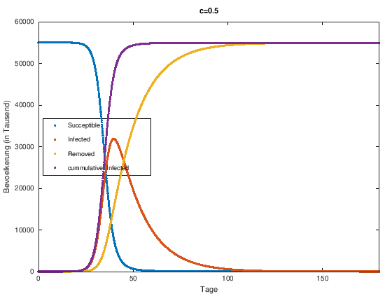

```matlab
% Anfangswerte als Spaltenvektor für S,I und R erstellen
y0=[B-I_0; I_0 ; 0];

c_v1=[0.5, 0.25, 0.3238]; %unterschiedliche c
for p=1:length(c_v1)
    c=c_v1(p);

    % Funktion f der rechten Seite des DGL-Systems y'=f(y,t)
    f=@(y,t)[-c*y(1)*y(2)/(r*B);c*y(1)*y(2)/B-w*y(2);w*y(2)-d*y(2)];

    %Löst das DGL-System
    y = lsode (f, y0, times);

    figure(p)
    plot (times, y (:,1),'.',times, y (:,2), '.', times, y (:,3),'.',times, y (:,3)+y (:,2),'.') % : alle Einträge der Zeilen (wenn : an erster Stelle     steht)
    title(["c=" num2str(c)])
     legend ("Succeptible","Infected", "Removed", "cummulative  Infected ","location", "west")
     xlabel ('Tage')
     ylabel ('Bevoelkerung (in Tausend)')
     axis([0,180, 0 ,60000])
endfor
```

### Ergebnis

Im Vergleich zum SI-Modell, bei dem die kumulierten Infizierten betrachtet wurden (da es kein Wechsel gibt von infected zu recovered) betrachten wir im SIR-Modell die aktuell Infizierten. Die kumulierten Infizierten entsprechen im SIR-Modell der Summe der aktuell Infizierten und Genesenen zu einem bestimmmten Zeitpunkt.

Im SIR-Modell lässt sich erkennen, dass je größer die Erkrankungsrate ist, desto höher der Peak der aktuell Infizierten ist. Die Infektion läuft schneller ab, was zur Folge hat, dass die Krankenhäuser bzw das Gesundheitssystem überlastet sind. Dementsprechend ist es wichtig, dass die Erkrankungsrate niedrig gehalten wird, sodass die Infektion langsamer verläuft und die Menschen über einen verteilten Zeitraum ins Krankenhaus kommen und nicht alle zum selben Zeitpunkt.

### Kritik

- konstantes c bildet Realität nicht ab (Kontaktverbot, Auswirkungen der Maßnahmen)
- keine Berücksichtigung der Verstorbenen
- Dunkelziffer der Infizierten ist in Realität höher

#### Hier Vergleichen wir das SIR-Modell mit den realen Werten vom RKI

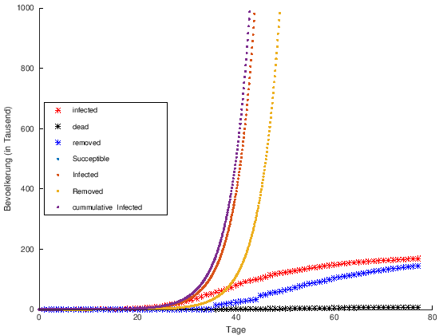

```matlab
%Corona-Daten geplottet
c=0.3238;
figure(99)
data = coronaData();
hold on
plot(data(1,:)./1000,'*r',data(2,:)./1000,'*k',data(3,:)./1000,'*b')
 axis([0,180, 0 ,55600])
plot (times, y (:,1),'.',times, y (:,2), '.', times, y (:,3),'.',times, y (:,3)+y (:,2),'.') % : alle Einträge der Zeilen (wenn : an erster Stelle steht)
 legend ("infected","dead","removed","Succeptible","Infected", "Removed", "cummulative  Infected ","location", "west")
 xlabel ('Tage')
 ylabel ('Bevoelkerung (in Tausend)')
 axis([0,80, 0 ,1000])
```

#### Ergebnis

- Zahl der behördlich erfassten Infizierten ist kleiner als berechnete Infizierte (steilere Kurven)-> Hinweis auf Dunkelziffer

#### Vergleich logistische SI-Modell mit dem SIR-Modell

##### mit Betrachtung unterschiedlicher Erkrankungsraten

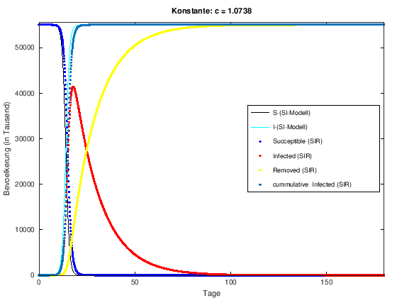

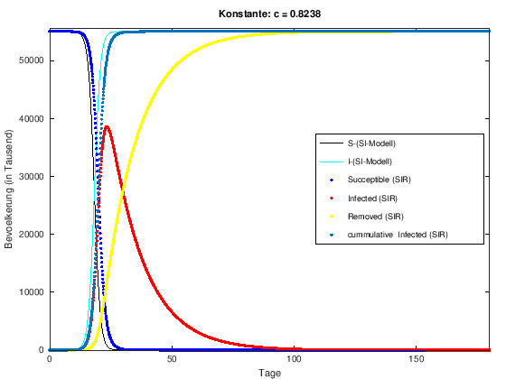

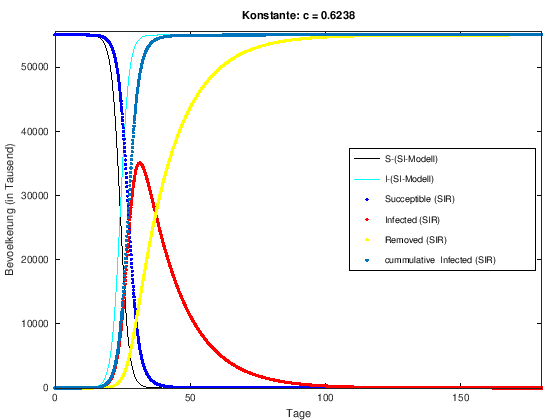

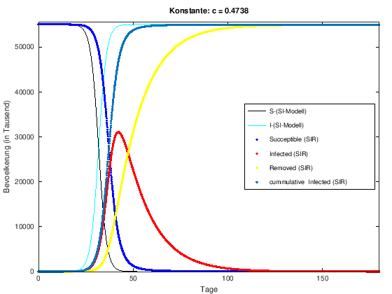

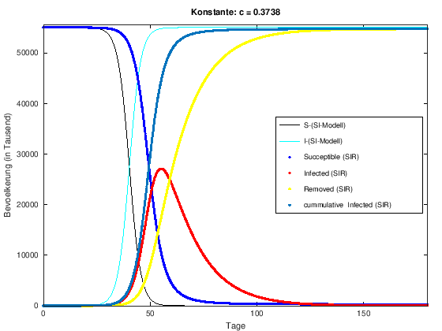

```matlab
% Anfangswerte als Spaltenvektor für S,I und R erstellen
z0=[B-16/1000; 16/1000]; %SI-Modell
y0=[B-16/1000; 16/1000; 0]; %SIR-Modell


for i=1:5
    cneu= c+0.05*i;
    c = cneu;
% Funktionen f,g der rechten Seite des DGL-Systems y'=f(y,t)
g=@(z,t)[-c*z(1)*z(2)/B; c*z(1)*z(2)/B];  %SI-Modell
f=@(y,t)[-c*y(1)*y(2)/(r*B);c*y(1)*y(2)/B-w*y(2);w*y(2)-d*y(2)]; %SIR-Modell

%Löst das DGL-System
z = lsode (g, z0, times); %SI-Modell
y = lsode (f, y0, times); %SIR-Modell


        figure (i);
        plot (times, z (:,1),'k',times, z (:,2), 'c',times, y (:,1),'.b',times, y (:,2), '.r', times, y (:,3),'.y',times, y (:,3)+y (:,2),'.');
        title(["Konstante: c = " num2str(c)]);
         legend ("S-(SI-Modell)", "I-(SI-Modell)","Succeptible (SIR)","Infected (SIR)", "Removed (SIR)", "cummulative  Infected (SIR) ","location",                    "east")
         xlabel ('Tage')
         ylabel ('Bevoelkerung (in Tausend)')
         axis([0,180, 0 ,55600])

endfor
```

#### Ergebnis

- Je höher die Erkrankungsrate ist, desto schneller laufen die Kompartimentmodelle (unabhängig vom einzelnen Modell) ab. Dies hat zur Folge, dass innerhalb kurzer Zeit die Individuen sich infizieren. -> Überlastung des Gesundheitssystems
- Je höher die Erkrungsrate ist, desto mehr nähern sich das SI-Modell und das SIR-Modell an, bis sie schießlich parallel ablaufen.
- Der Einfluss der Genesungsrate ist bei hohem c sehr gering: die Zahl der aktuell Infizierten steigt viel schneller an als dass die Genesungsrate positive Auswirkungen auf die Infizierten hat (Infiziertenzahl wird geringer)

## Modifiziertes SIR-Modell

Im folgenden Modell wird das ursprüngliche SIR-Modell modifiziert. Hier liegt die Annahme zugrunde, dass nur ein Bruchteil der tatsächlichen Infiziertenzahl behördlich erfasst wird (gemeldete Fälle des RKI < tatsächliche Fälle). Dieses Verhältnis wird mit r beschrieben. Setzen wir r=0.1 wird angenommen, dass lediglich 10% der tatsächlich Infizierten gemeldet werden. Gründe dafür können sein:

- viele Infektionen verlaufen asymptomatisch bis symptomfrei
- falsch-negative Tests: Testergebnisse sind fälschlicherweise negativ, obwohl eine Infektion vorliegt
- Personen versuchen Tests zu umgehen, um z.B. eine Quarantäne zu vermeiden (aktuell: v.a. Reiserückkehrer betroffen)
- Personen mit nicht eindeutigen Krankheitssymptomen wurden vom Hausarzt nicht an entsprechende Testzentren überwiesen

Es gelten die folgenden Gleichungen: \begin{eqnarray} S'(t)&=&-\frac{c}{rB}S(t)I(t)\\ I'(t)&=&\frac{c}{B}S(t)I(t)-wI(t)\\ R'(t)&=&wI(t)- dI(t)\\ \\ S(t0)&=&B-I0\\ I(t0)&=&I0\\ R(t0)&=&0 \end{eqnarray} wobei  
d= konstante Sterberate mit der die Infizierten aus der Gesamtbevölkerung aussteigen  
r= konstanter Faktor, der den Prozentualanteil der durch Tests erfassten Infizierten beschreibt  
R beschreibt die Genesenen ohne Tote

Die Erhaltungsgleichung \begin{eqnarray} (S + \frac{I}{r} + \frac{R}{r})'=-dI \end{eqnarray} besagt, dass sich die Gesamtbevölkerung \begin{eqnarray} S + \frac{I}{r} + \frac{R}{r} \end{eqnarray} um die verstorbenen Infizierten verringert.  
Sofern r=1 und d=0 folgt das SIR-Modell.

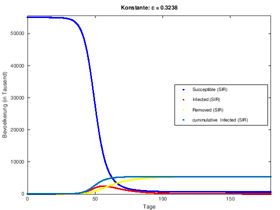

```matlab
% Anfangswerte als Spaltenvektor für S,I und R erstellen
y0=[B-16/1000; 16/1000; 0];
z0=[B-16/1000; 16/1000];

rneu=r-0.9; %somit wird r zu 0,1
cneu=0.3238;
dneu=d+0.003; %somit wird d zu 0.003

% Funktionen f der rechten Seite des DGL-Systems y'=f(y,t)
f=@(y,t)[-cneu*y(1)*y(2)/(rneu*B);cneu*y(1)*y(2)/B-w*y(2);w*y(2)-d*y(2)]; %SIR-Modell

%Löst das DGL-System
y = lsode (f, y0, times); %SIR-Modell


        figure (i);
        plot (times, y (:,1),'.b',times, y (:,2), '.r', times, y (:,3),'.y',times, y (:,3)+y (:,2),'.');
        title(["Konstante: c = " num2str(cneu)]);
         legend ("Succeptible (SIR)","Infected (SIR)", "Removed (SIR)", "cummulative  Infected (SIR) ","location", "east")
         xlabel ('Tage')
         ylabel ('Bevoelkerung (in Tausend)')
         axis([0,180, 0 ,55600])
```

#### Ergebnis

Es ist ersichtlich, dass Infizierten- und Genesenen-Anzahl deutlich kleiner ist als beim SIR-Modell. Dies liegt an den nicht erfassten Infizierten, die in diesem Modell nicht sichtbar sind.  
Jedoch verringert sich die Anzahl der Gefährdeteten wie im SIR-Moodell, da die Menschen sich weiterhin infizieren. Durch das teilen mit r=0.1 in S wird S mal 10 genommen, sodass der Unterschied hier deutlich wird.

#### Kritik

- Sterberate ist in der Realtiät abhängig von Faktoren wie Alter der Erkrankten, Vorerkrankungen, etc. und daher eigentlich variable und nicht wie hier konstant -> zur Zeit erkranken immer mehr jüngere Menschen weshalb die Sterberate momentan niedriger ist als zu Beginn der Coronaverbreitung